# Depuración de atípicos: 1.070 → 970

Cadena de preprocesamiento del PCA · Coffee Quality Institute

Juan Sebastián Guayazán · Esteban Valente · Diego Nocua

20 de noviembre de 2026

**En resumen.** Se parte de 1.070 lotes. Con la distancia de Mahalanobis correcta (umbral χ² al 97,5 %, 8 g.l. = 17,53) se marcan 100 atípicos multivariados (9,3 %) y quedan 970. Con esos 970 lotes ninguna variable supera |asimetría| > 1, así que el PCA final solo estandariza. Un error de cálculo anterior marcaba 404 lotes; la cifra correcta es 100.

# Qué responde este informe

**Pregunta:** ¿qué lotes hay que retirar antes del PCA para que unos pocos casos extremos no dominen las componentes, y en qué orden se prepara cada variable?

Este documento reúne la cadena de depuración que usan los análisis de PCA y los métodos posteriores. El resultado final del PCA está en pca_final.

| Paso | Qué se hace | Resultado |
| --- | --- | --- |
| 1 | Base de 1.070 lotes, Yeo-Johnson solo donde hay asimetría y estandarización | Matriz de partida |
| 2 | Distancia de Mahalanobis sobre la base | Qué lotes son atípicos multivariados |
| 3 | Una sola pasada del filtro y comprobación del cálculo | 970 lotes |
| 4 | Matriz final guardada | `datos/datos_final_970.rds` |

# 1. Base de 1.070 lotes y transformación Yeo-Johnson selectiva

**Qué hacemos y por qué.** Se aplica el filtro original (altitud entre 0 y 3.000 m y registros completos) y se eligen 8 variables: siete atributos sensoriales y la altitud. El **orden** de las operaciones importa:

1. Medir la asimetría de cada variable.
2. Transformar con Yeo-Johnson **solo** las que superan |asimetría| > 1.
3. Estandarizar (centrar en 0 y dividir entre la desviación estándar).
4. Recién entonces medir qué lotes son atípicos.

Si se estandarizara antes de transformar, los parámetros de la transformación quedarían calculados sobre datos ya centrados y la corrección de asimetría perdería sentido.

```r
# Preprocesamiento común para todos los métodos.
# Base: 1.070 lotes con filtro original. Yeo-Johnson selectivo (|asimetría|>1) y estandarización,
# λ estimados sobre la base de cada análisis. Versión "sin atípicos": Mahalanobis sobre la propia
# matriz transformada y estandarizada; se re-estiman λ y estandarización sobre el subconjunto.
suppressMessages(library(car))
d <- read.csv("../data/arabica_data_cleaned.csv")
vars14 <- c("Aroma","Flavor","Aftertaste","Acidity","Body","Balance","Uniformity","Clean.Cup","Sweetness","Cupper.Points","Moisture","Category.One.Defects","Category.Two.Defects","altitude_mean_meters")
b <- d[!is.na(d$altitude_mean_meters) & d$altitude_mean_meters > 0 & d$altitude_mean_meters <= 3000, ]
b <- b[complete.cases(b[, vars14]), ]
d0 <- read.csv("../data/arabica_data_cleaned.csv")
vars14 <- c("Aroma","Flavor","Aftertaste","Acidity","Body","Balance","Uniformity","Clean.Cup","Sweetness","Cupper.Points","Moisture","Category.One.Defects","Category.Two.Defects","altitude_mean_meters")
bb <- d0[!is.na(d0$altitude_mean_meters) & d0$altitude_mean_meters > 0 & d0$altitude_mean_meters <= 3000, ]
bb <- bb[complete.cases(bb[, vars14]), ]
X8 <- bb[, c("Aroma","Flavor","Aftertaste","Acidity","Body","Balance","Cupper.Points","altitude_mean_meters")]
names(X8) <- c("Aroma","Sabor","Retrogusto","Acidez","Cuerpo","Balance","Puntaje.Catador","Altitud")

preprocess <- function(R) {
  sk <- sapply(R, function(x) mean((x - mean(x))^3) / sd(x)^3)
  yj <- names(sk)[abs(sk) > 1]
  T <- R
  lam <- NULL
  if (length(yj) > 0) {
    lam <- coef(powerTransform(R[, yj, drop = FALSE], family = "yjPower"), round = FALSE)
    for (v in yj) T[[v]] <- yjPower(R[[v]], lam[v])
  }
  list(raw = R, trans = T, Z = as.data.frame(scale(T)), yj = yj, lambdas = lam, skew = sk)
}

p1070 <- preprocess(X8)
md <- mahalanobis(p1070$Z, colMeans(p1070$Z), cov(p1070$Z))
keep <- md <= qchisq(0.975, 8)
psin <- preprocess(X8[keep, ])

saveRDS(p1070, "../datos/base_1070.rds")
saveRDS(psin, "../datos/base_sin_atipicos.rds")

res1 <- data.frame(
  Base = c("1.070 lotes (antes de retirar atípicos)", "970 lotes (después de retirar atípicos)"),
  Lotes = c(nrow(p1070$Z), nrow(psin$Z)),
  `Variables con Yeo-Johnson` = c(paste(p1070$yj, collapse = ", "), if (length(psin$yj)) paste(psin$yj, collapse = ", ") else "ninguna"),
  check.names = FALSE)
tabla(res1, align = "lrl", caption = "Qué se transformó en cada base")
```

Qué se transformó en cada base

| Base | Lotes | Variables con Yeo-Johnson |
| --- | --- | --- |
| 1.070 lotes (antes de retirar atípicos) | 1.070 | Aroma, Sabor, Retrogusto, Acidez, Cuerpo, Balance, Puntaje.Catador |
| 970 lotes (después de retirar atípicos) | 970 | ninguna |

**Cómo se lee.** En la base de 1.070 lotes, los siete atributos sensoriales tienen asimetría muy negativa (por debajo de −1), así que se transforman con Yeo-Johnson. Una vez retirados los atípicos (sección 3), la misma regla aplicada a los 970 lotes **no marca ninguna variable**: la asimetría que había era causada por esos pocos lotes extremos.

# 2. Distancia de Mahalanobis en la base de 1.070

**Qué hacemos y por qué.** La distancia de Mahalanobis mide qué tan raro es un lote **considerando todas las variables a la vez y sus correlaciones**: un lote puede tener cada puntaje no muy extremo y aun así ser una combinación improbable. Se compara con el cuantil 97,5 % de una χ² con 8 grados de libertad (una por variable): si los datos fueran normales, solo el 2,5 % de los lotes superaría ese umbral.

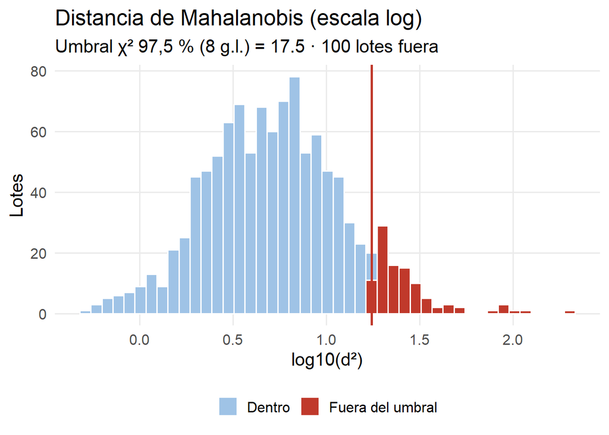

```r
suppressMessages(library(ggplot2))
Z <- readRDS("../datos/base_1070.rds")$Z
md2 <- mahalanobis(Z, colMeans(Z), cov(Z)); lim <- qchisq(0.975, 8)
df <- data.frame(l = log10(md2), out = md2 > lim)
g <- ggplot(df, aes(l, fill = out)) + geom_histogram(bins = 45, color = "white") +
  geom_vline(xintercept = log10(lim), color = "#c0392b", linewidth = 1) +
  scale_fill_manual(values = c("FALSE" = "#9fc3e6", "TRUE" = "#c0392b"), labels = c("Dentro", "Fuera del umbral")) +
  labs(title = "Distancia de Mahalanobis (escala log)", subtitle = sprintf("Umbral χ² 97,5 %% (8 g.l.) = %.1f · %d lotes fuera", lim, sum(df$out)), x = "log10(d²)", y = "Lotes", fill = NULL) +
  theme_minimal(base_size = 15) + theme(panel.grid.minor = element_blank(), plot.background = element_rect(fill = NA, color = NA), panel.background = element_rect(fill = NA, color = NA), legend.position = "bottom")
ggsave("figuras/proceso/1070_mahalanobis.png", g, width = 8, height = 6.5, dpi = 200, bg = "transparent")
g
```

**Cómo se lee.** La línea roja es el umbral (17,53). Los lotes a su derecha (en rojo) son los atípicos multivariados: **100** de 1.070, es decir, 9,3 %. Se usa escala logarítmica porque las distancias de los lotes más extraños son muchísimo mayores que las del resto.

# 3. Cadena de depuración: 1.070 → 970 (una sola pasada)

> **Corrección (revisión de Diego).** La versión anterior calculaba la distancia como `rowSums((pre$x / pre$sdev)^2)`. En R, dividir una matriz entre un vector recicla el vector **por filas**, no por columnas: cada score quedaba dividido entre la desviación de una componente que no le correspondía. Por eso salían 404 «atípicos» en vez de 100, y la cadena terminaba en 666 y luego en 627 lotes. Lo correcto es dividir cada columna de scores entre su propia desviación con `sweep(pre$x, 2, pre$sdev, "/")`. Con todas las componentes, esa suma es exactamente la distancia de Mahalanobis sobre la matriz estandarizada, la misma de la sección 2.

**Qué hacemos y por qué.** Se ajusta un PCA preliminar sobre los 1.070 lotes y se calcula la distancia de cada lote sobre sus scores. Hacemos tres comprobaciones: (a) que la distancia correcta coincide con `mahalanobis()`, (b) cuántos lotes marcaba el cálculo erróneo anterior, y (c) cuántos marcaría una segunda pasada.

El filtro se aplica **una sola vez**. Al quitar los extremos la nube se encoge y otros lotes pasan a parecer lejanos; repetir el filtro seguiría quitando lotes en cada vuelta sin terminar.

```r
suppressMessages(library(ggplot2))
b <- readRDS("../datos/base_1070.rds")
T <- b$trans
pre <- prcomp(T, center = TRUE, scale. = TRUE)
lim <- qchisq(0.975, 8)

# Distancia correcta: cada columna de scores entre su propia desviación
dm2_pre <- rowSums(sweep(pre$x, 2, pre$sdev, "/")^2)
out1 <- dm2_pre > lim

# Comprobación: coincide con la distancia de Mahalanobis de la sección 2
md_ref <- mahalanobis(b$Z, colMeans(b$Z), cov(b$Z))
dif_max <- max(abs(dm2_pre - md_ref))

# Lo que daba el código anterior (reciclaje por filas), solo para documentar el error
dm2_mal <- rowSums((pre$x / pre$sdev)^2)

# PCA sobre los 970 lotes (λ y estandarización re-estimados sobre el subconjunto)
psin <- readRDS("../datos/base_sin_atipicos.rds")
stopifnot(nrow(psin$Z) == sum(!out1))
pf <- prcomp(psin$Z, center = TRUE, scale. = TRUE)

# Solo referencia: una segunda pasada sobre los 970 (no se aplica)
md_2a <- mahalanobis(psin$Z, colMeans(psin$Z), cov(psin$Z))

comprob <- data.frame(
  Comprobación = c("Lotes marcados con el cálculo correcto (sweep)",
                   "Máxima diferencia con mahalanobis() de la sección 2",
                   "Lotes marcados con el código anterior (error de reciclaje)",
                   "Lotes que quedan tras la única pasada",
                   "Lotes que marcaría una segunda pasada (no se retiran)"),
  Valor = c(as.character(sum(out1)), format(signif(dif_max, 3), scientific = TRUE), as.character(sum(dm2_mal > lim)),
            as.character(sum(!out1)), as.character(sum(md_2a > lim))))
tabla(comprob, align = "lr", caption = "Comprobaciones de la depuración")
```

Comprobaciones de la depuración

| Comprobación | Valor |
| --- | --- |
| Lotes marcados con el cálculo correcto (sweep) | 100 |
| Máxima diferencia con mahalanobis() de la sección 2 | 1.71e-13 |
| Lotes marcados con el código anterior (error de reciclaje) | 404 |
| Lotes que quedan tras la única pasada | 970 |
| Lotes que marcaría una segunda pasada (no se retiran) | 63 |

```r
varianza <- data.frame(
  Modelo = c("PCA preliminar (1.070 lotes)", "PCA final (970 lotes)"),
  CP1 = round(summary(pre)$importance[2, 1] * 100, 1), CP2 = round(summary(pre)$importance[2, 2] * 100, 1), CP3 = round(summary(pre)$importance[2, 3] * 100, 1))
varianza[2, 2:4] <- round(summary(pf)$importance[2, 1:3] * 100, 1)
tabla(setNames(varianza, c("Modelo", "CP1 (%)", "CP2 (%)", "CP3 (%)")), align = "lrrr", caption = "Varianza explicada antes y después de retirar los atípicos")
```

Varianza explicada antes y después de retirar los atípicos

| Modelo | CP1 (%) | CP2 (%) | CP3 (%) |
| --- | --- | --- | --- |
| PCA preliminar (1.070 lotes) | 67,2 | 11,9 | 5,3 |
| PCA final (970 lotes) | 69,3 | 11,6 | 5,3 |

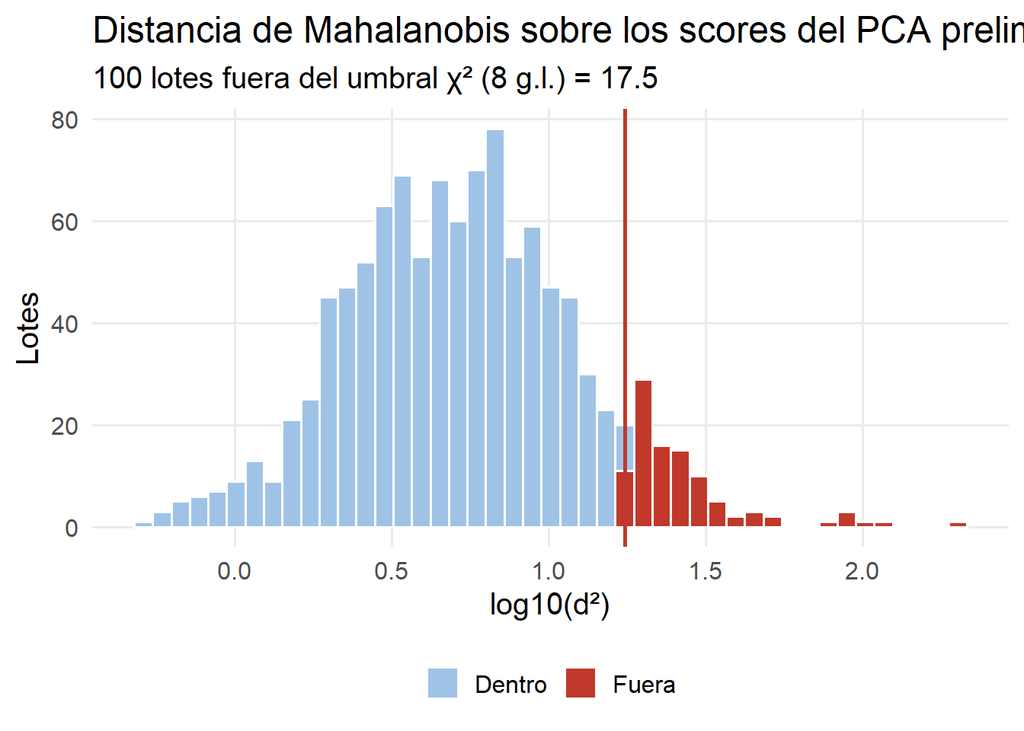

```r
th <- theme_minimal(base_size = 15) + theme(panel.grid.minor = element_blank(), plot.background = element_rect(fill = NA, color = NA), panel.background = element_rect(fill = NA, color = NA), legend.position = "bottom")
g3 <- ggplot(data.frame(l = log10(dm2_pre), out = out1), aes(l, fill = out)) + geom_histogram(bins = 45, color = "white") +
  geom_vline(xintercept = log10(lim), color = "#c0392b", linewidth = 1) + scale_fill_manual(values = c("FALSE" = "#9fc3e6", "TRUE" = "#c0392b"), labels = c("Dentro", "Fuera")) +
  labs(title = "Distancia de Mahalanobis sobre los scores del PCA preliminar", subtitle = sprintf("%d lotes fuera del umbral χ² (8 g.l.) = %.1f", sum(out1), lim), x = "log10(d²)", y = "Lotes", fill = NULL) + th
ggsave("figuras/proceso/paso1_mahalanobis_pca_prelim.png", g3, width = 8, height = 6.5, dpi = 200, bg = "transparent")
g3
```

**Cómo se lee.**

- La distancia calculada con `sweep` coincide con `mahalanobis()` (diferencia del orden de 10⁻¹³, solo error numérico): el cálculo es correcto.
- El cálculo anterior marcaba **404** lotes por el error de reciclaje; el correcto marca **100**.
- Una segunda pasada marcaría 63 lotes más (por azar se esperarían unos 24). No se retiran, por la razón explicada arriba.
- El PCA preliminar con los 1.070 lotes y el final con los 970 dan porcentajes de varianza explicada parecidos; la diferencia es que el segundo ya no está dominado por los casos extremos y no necesita transformaciones.

# 4. Matriz final de 970 lotes

**Qué hacemos.** Se guarda la matriz final en `datos/datos_final_970.rds`, con la estructura que leen pca_final, figuras_pca, los métodos exploratorios y la app de Shiny: datos limpios, variables transformadas (ninguna), índices de los atípicos y datos originales. Los archivos `datos_final_666.rds` y `datos_final_627.rds` de versiones anteriores se eliminaron porque provenían del error de Mahalanobis descrito arriba.

```r
psin <- readRDS("../datos/base_sin_atipicos.rds")
p1070 <- readRDS("../datos/base_1070.rds")
md <- mahalanobis(p1070$Z, colMeans(p1070$Z), cov(p1070$Z))
idx_atipicos <- which(md > qchisq(0.975, 8))
saveRDS(list(datos_limpio = psin$trans,
             vars_transformar = psin$yj,
             lambdas = psin$lambdas,
             idx_atipicos = idx_atipicos,
             datos_originales = psin$raw),
        "../datos/datos_final_970.rds")
tabla(data.frame(Elemento = c("Lotes retirados", "Matriz final (lotes × variables)", "Variables transformadas con Yeo-Johnson"),
                 Valor = c(sprintf("%d de %d", length(idx_atipicos), nrow(p1070$Z)),
                           sprintf("%d × %d", nrow(psin$trans), ncol(psin$trans)),
                           if (length(psin$yj)) paste(psin$yj, collapse = ", ") else "ninguna")),
      align = "lr", caption = "Contenido de la matriz final")
```

Contenido de la matriz final

| Elemento | Valor |
| --- | --- |
| Lotes retirados | 100 de 1070 |
| Matriz final (lotes × variables) | 970 × 8 |
| Variables transformadas con Yeo-Johnson | ninguna |

# Conclusiones

1. Se retiran **100 lotes atípicos multivariados** (9,3 % de 1.070) con una sola pasada de Mahalanobis; quedan **970**.
2. Con los 970 lotes ninguna variable supera |asimetría| 1: **el PCA final solo estandariza**.
3. El error de reciclaje que daba 404 atípicos (y matrices de 666 y 627 lotes) está corregido y documentado.
4. Es una limitación declarada que una segunda pasada marcaría más lotes: se decidió no repetir el filtro.